# Report

Varad Srivastava

March 21, 2019

# Analysis of Industries :

## 1. No. of Industries :

Source : Zila Spider Report (http://updes.up.nic.in/spiderreports/industryReports.jsp) Talika 35 and 36

#### Let’s take as input the raw data.

```r
data <- read.csv("data_files/no_of_industries.csv", header = TRUE)
```

#### Visualizing the data:

Using box plot :

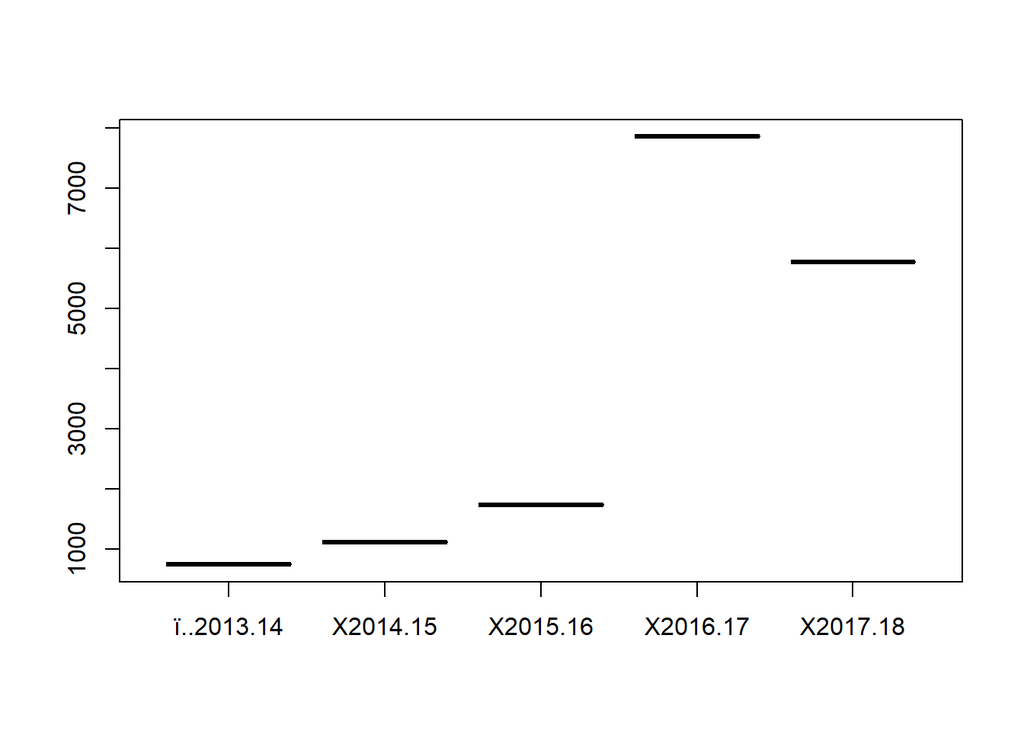

Using Histogram/Bar Chart:

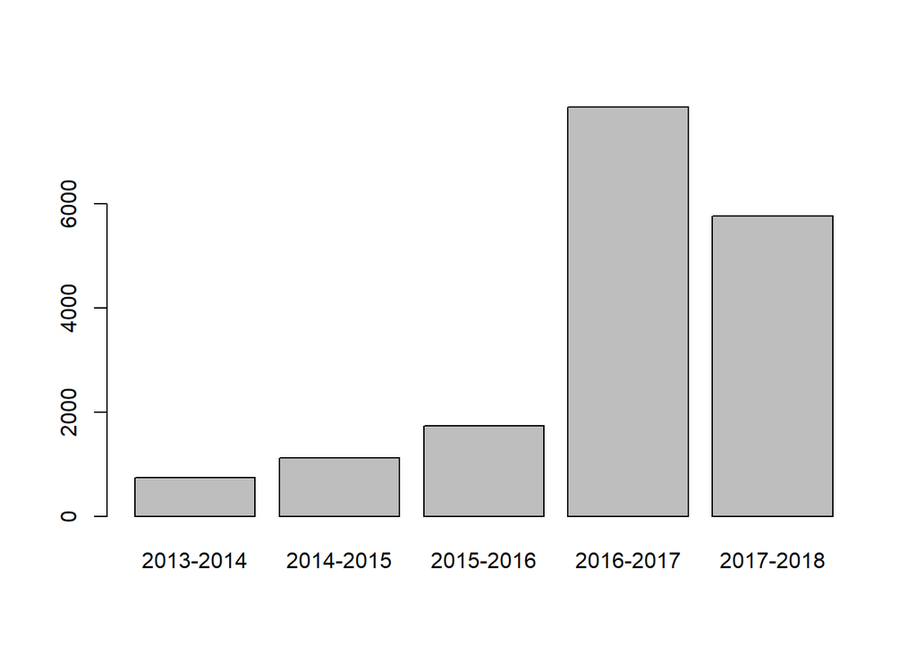

#### Analysis of Data:

Summary of data:

```
##    ï..2013.14     X2014.15       X2015.16       X2016.17       X2017.18
##  Min.   :744   Min.   :1118   Min.   :1738   Min.   :7855   Min.   :5768
##  1st Qu.:744   1st Qu.:1118   1st Qu.:1738   1st Qu.:7855   1st Qu.:5768
##  Median :744   Median :1118   Median :1738   Median :7855   Median :5768
##  Mean   :744   Mean   :1118   Mean   :1738   Mean   :7855   Mean   :5768
##  3rd Qu.:744   3rd Qu.:1118   3rd Qu.:1738   3rd Qu.:7855   3rd Qu.:5768
##  Max.   :744   Max.   :1118   Max.   :1738   Max.   :7855   Max.   :5768
```

### **Conclusion** : No. of industuries have been increasing since the last few years, recording a suprising jump, in 2016-17, possibily due to ease of doing business. Also to be noted is that, after 2016-17, no. of industries have seen a sudden decline, possibly due to cash crunch due to demonetisation.

## 2a. Types of Industries according to labour :

Source : Zila Spider Report (http://updes.up.nic.in/spiderreports/industryReports.jsp) Talika 37

#### Let’s take as input the raw data.

```r
data <- read.csv("data_files/industries_labour.csv", header = TRUE)
data <- cbind(Years = c("2017-18","2016-17","2015-16"), data)
```

#### Visualizing the data:

Using Histogram/Bar Chart:

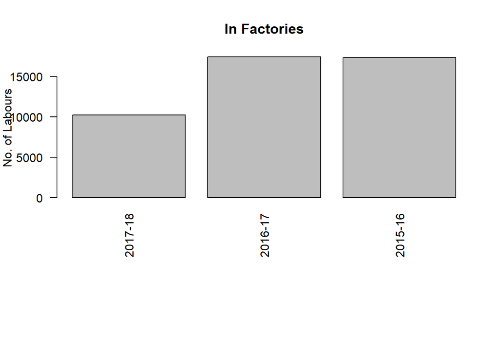

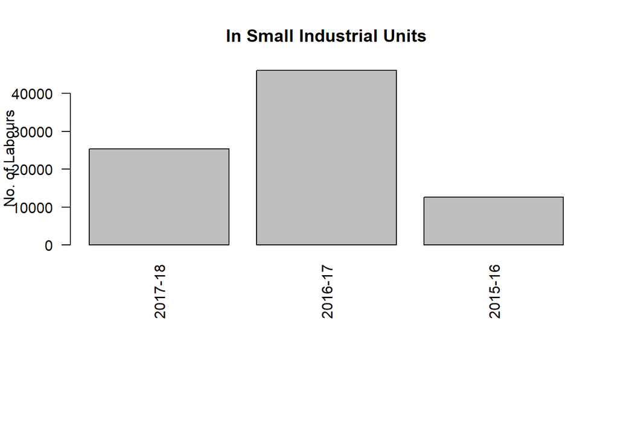

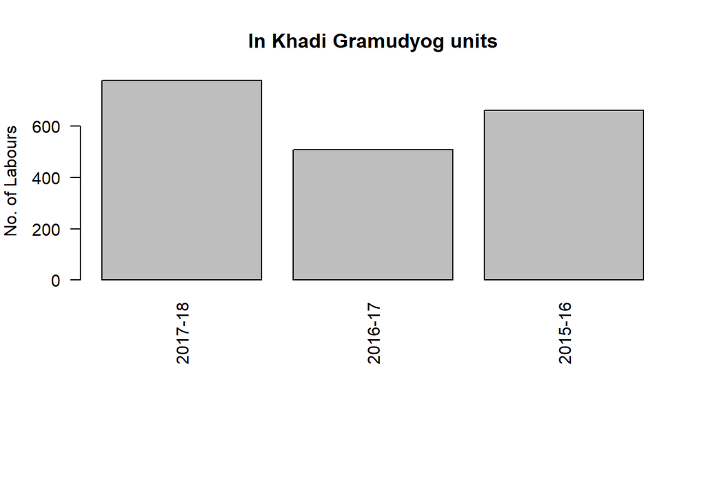

#### Analysis of Data:

Summary of data:

```
##      Years    ï..Factories   Small.Industrial.Units Khadi.Gramudyog.units
##  2015-16:1   Min.   :10229   Min.   :12661          Min.   :508.0
##  2016-17:1   1st Qu.:13781   1st Qu.:19018          1st Qu.:584.5
##  2017-18:1   Median :17333   Median :25375          Median :661.0
##              Mean   :14999   Mean   :28027          Mean   :649.0
##              3rd Qu.:17385   3rd Qu.:35711          3rd Qu.:719.5
##              Max.   :17436   Max.   :46046          Max.   :778.0
```

### **Conclusion** : Most growth has been witnessed in Khadi Gramudyog units and in small industrial units, possibily indicating a shift to smaller units, maybe because of government’s initiatives to build up entrpreneruship avenues.

## 2c. Types of Industries according to Ownership :

Source : Zila Spider Report (http://updes.up.nic.in/spiderreports/industryReports.jsp) Talika 36

#### Let’s take as input the raw data.

```r
data <- read.csv("data_files/industries_ownership.csv", header = TRUE)
```

#### Visualizing the data:

Using box plot :

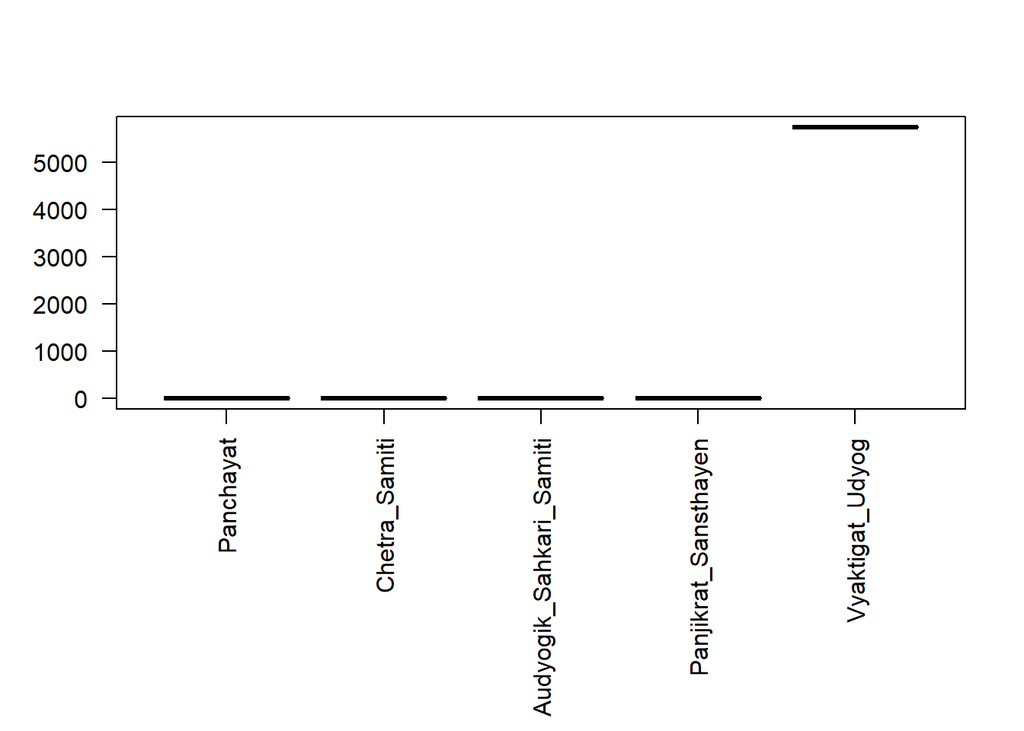

Using Histogram/Bar Chart:

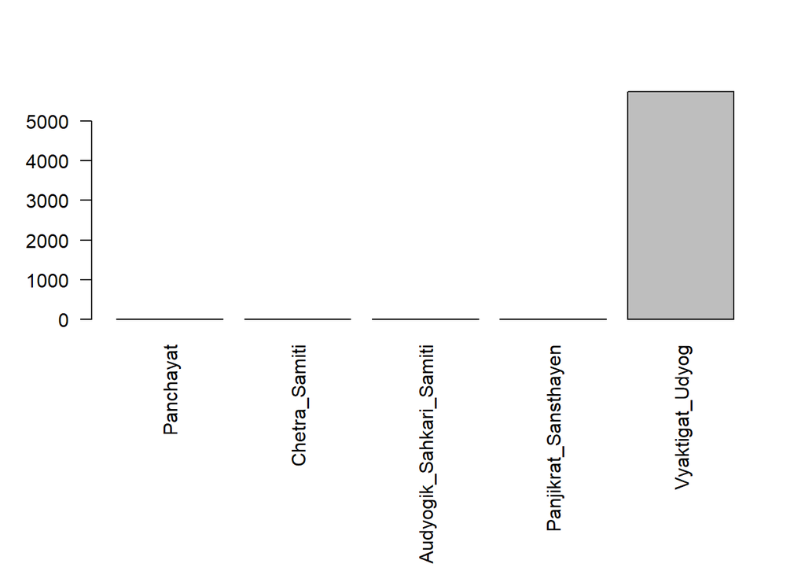

#### Analysis of Data:

Summary of data:

```
##   ï..Panchayat Chetra.Samiti Auduogik.Sahkari.Samiti Panjikrat.Sansthayen
##  Min.   :0     Min.   :0     Min.   :0               Min.   :0
##  1st Qu.:0     1st Qu.:0     1st Qu.:0               1st Qu.:0
##  Median :0     Median :0     Median :0               Median :0
##  Mean   :0     Mean   :0     Mean   :0               Mean   :0
##  3rd Qu.:0     3rd Qu.:0     3rd Qu.:0               3rd Qu.:0
##  Max.   :0     Max.   :0     Max.   :0               Max.   :0
##  Vyaktigat.Udyog
##  Min.   :5730
##  1st Qu.:5730
##  Median :5730
##  Mean   :5730
##  3rd Qu.:5730
##  Max.   :5730
```

# Analysis of Electricity

## No. Electricity connections in rural areas :

Source : Zila Spider Report (http://updes.up.nic.in/spiderreports/gettable48Report.action) Talika 48

#### Let’s take as input the raw data.

```r
data <- read.csv("data_files/electric_connections.csv", header = TRUE)
```

#### Visualizing the data:

Using box plot :

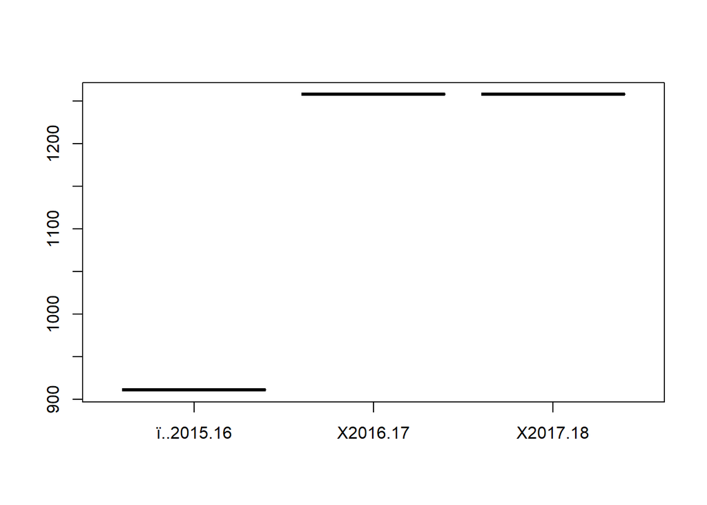

Using Histogram/Bar Chart:

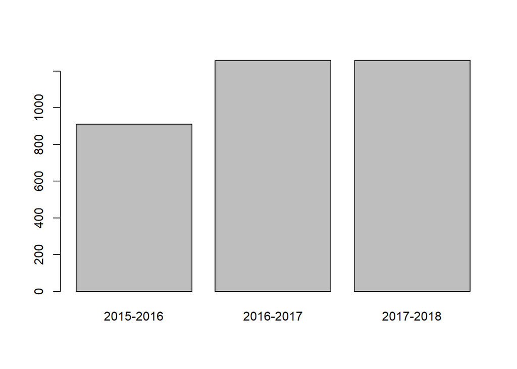

#### Analysis of Data:

Summary of data:

```
##    ï..2015.16     X2016.17       X2017.18
##  Min.   :911   Min.   :1258   Min.   :1258
##  1st Qu.:911   1st Qu.:1258   1st Qu.:1258
##  Median :911   Median :1258   Median :1258
##  Mean   :911   Mean   :1258   Mean   :1258
##  3rd Qu.:911   3rd Qu.:1258   3rd Qu.:1258
##  Max.   :911   Max.   :1258   Max.   :1258
```

# Analysis of Education

## No. schools, colleges and universities :

Source : Zila Spider Report (http://updes.up.nic.in/spiderreports/gettable39Report.action) Talika 39

#### Let’s take as input the raw data.

```r
data <- read.csv("data_files/education_nos.csv", header = TRUE)
```

#### Visualizing the data:

Using box plot :

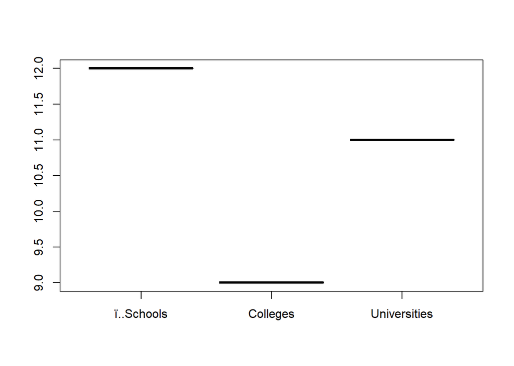

Using Histogram/Bar Chart:

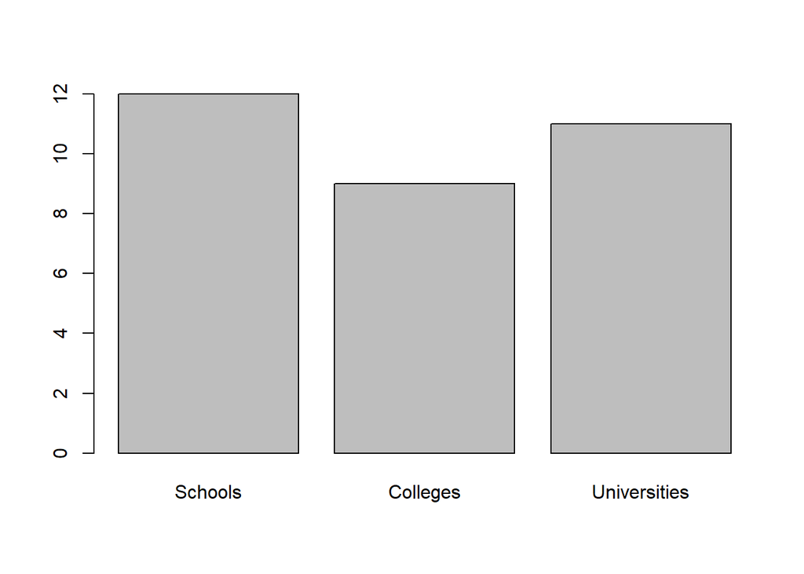

#### Analysis of Data:

Summary of data:

```
##    ï..Schools    Colleges  Universities
##  Min.   :12   Min.   :9   Min.   :11
##  1st Qu.:12   1st Qu.:9   1st Qu.:11
##  Median :12   Median :9   Median :11
##  Mean   :12   Mean   :9   Mean   :11
##  3rd Qu.:12   3rd Qu.:9   3rd Qu.:11
##  Max.   :12   Max.   :9   Max.   :11
```

### **Conclusion** : No. of educational institutions are significant in the district, with the presence of even notable institutions like BHU and IIT. However,much can be done on the front of colleges and schools. With the district population growing as a fast pace, with the influx of rural population from nearby villages, necessity for more schools and colleges is going to increase.

## No. of teachers :

Source : Zila Spider Report (http://updes.up.nic.in/spiderreports/gettable41Report.action) Talika 41

#### Let’s take as input the raw data.

```r
data <- read.csv("data_files/teachers.csv", header = TRUE)
```

#### Visualizing the data:

Using box plot :

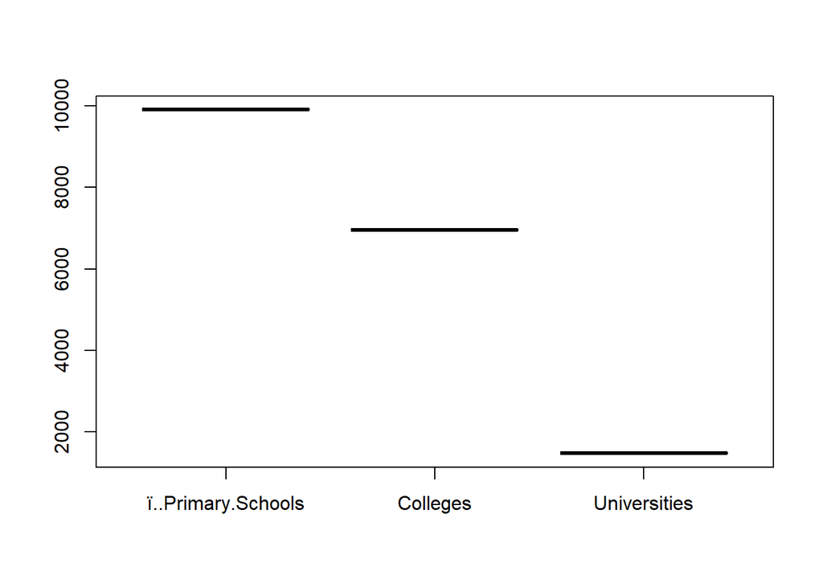

Using Histogram/Bar Chart:

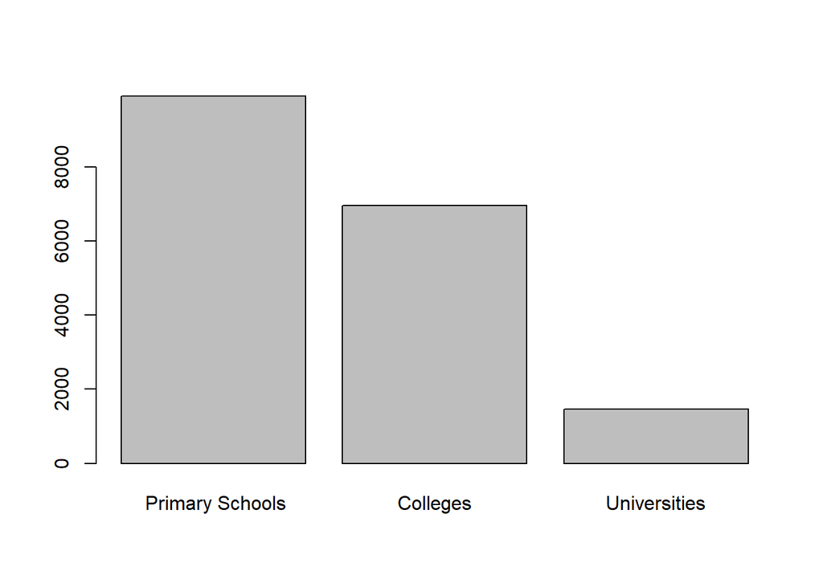

#### Analysis of Data:

Summary of data:

```
##  ï..Primary.Schools    Colleges     Universities
##  Min.   :9908       Min.   :6956   Min.   :1467
##  1st Qu.:9908       1st Qu.:6956   1st Qu.:1467
##  Median :9908       Median :6956   Median :1467
##  Mean   :9908       Mean   :6956   Mean   :1467
##  3rd Qu.:9908       3rd Qu.:6956   3rd Qu.:1467
##  Max.   :9908       Max.   :6956   Max.   :1467
```

### **Conclusion** : No. of teachers although show a positive feature, but the quality of education remains low, indicating, lack of quality, not quantity. The screening process of teachers need to match the necessities of the modern world.

# Analysis of Irrigation

## Irrigation Area :

Source : Zila Spider Report (http://updes.up.nic.in/spiderreports/gettable18Report.action) Talika 18

#### Let’s take as input the raw data.

```r
data <- read.csv("data_files/irrigation_area.csv", header = TRUE)
```

#### Visualizing the data:

Using box plot :

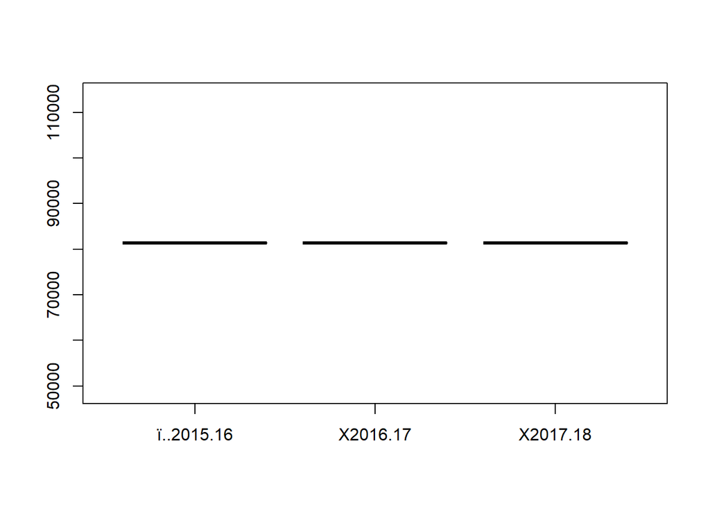

Using Histogram/Bar Chart:

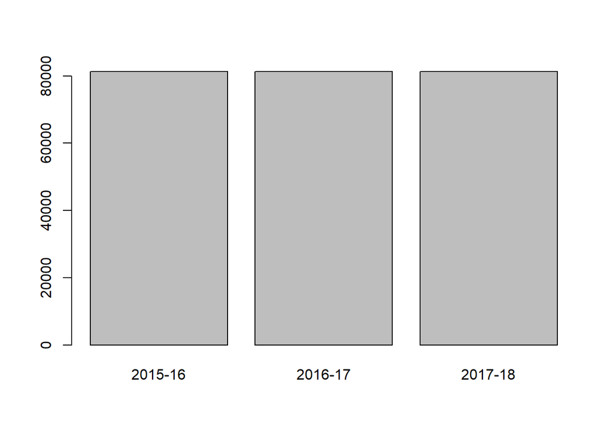

#### Analysis of Data:

Summary of data:

```
##    ï..2015.16       X2016.17        X2017.18
##  Min.   :81319   Min.   :81319   Min.   :81319
##  1st Qu.:81319   1st Qu.:81319   1st Qu.:81319
##  Median :81319   Median :81319   Median :81319
##  Mean   :81319   Mean   :81319   Mean   :81319
##  3rd Qu.:81319   3rd Qu.:81319   3rd Qu.:81319
##  Max.   :81319   Max.   :81319   Max.   :81319
```

### **Conclusion** : Amount of irrigation area shows up more or less, over the last three years, indicating a fault in government records.

## Number of canals and ponds :

Source : Zila Spider Report (http://updes.up.nic.in/spiderreports/gettable18Report.action) Talika 18

#### Let’s take as input the raw data.

```r
data <- read.csv("data_files/ponds_canals.csv", header = TRUE)
```

#### Visualizing the data:

Using box plot :

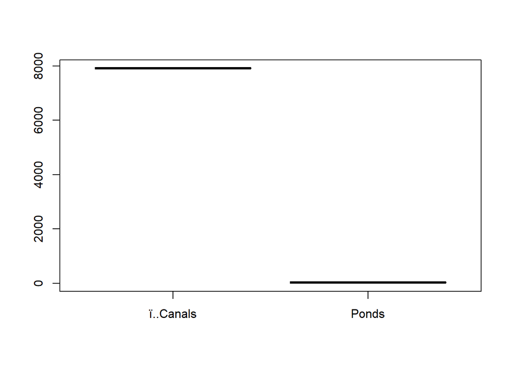

Using Histogram/Bar Chart:

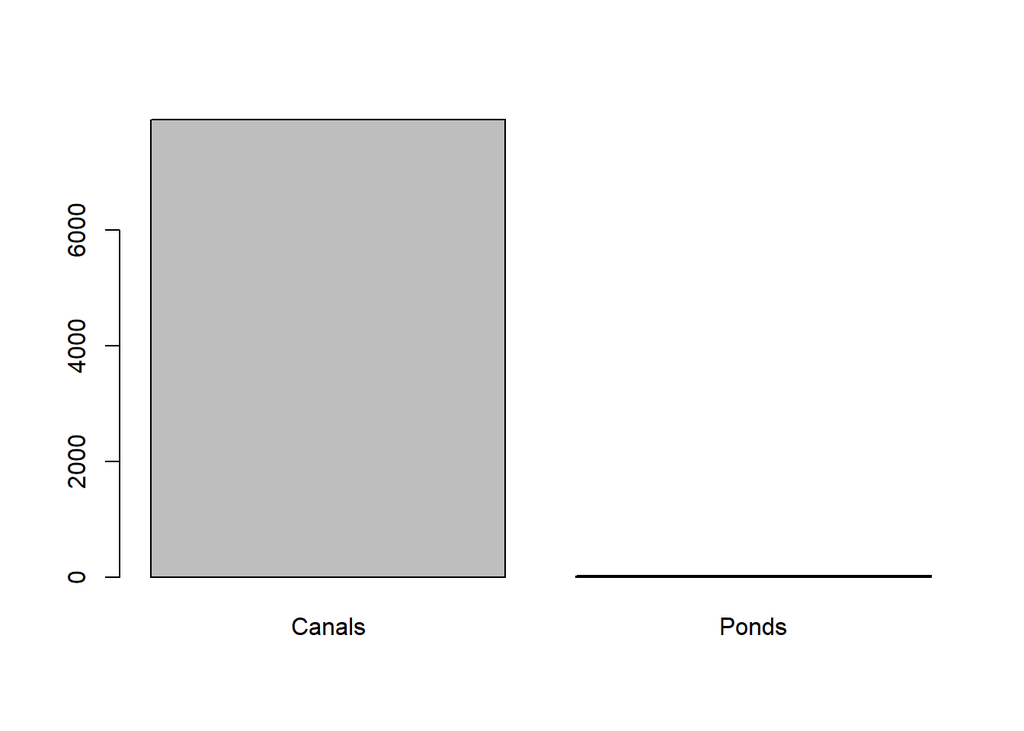

#### Analysis of Data:

Summary of data:

```
##    ï..Canals        Ponds
##  Min.   :7909   Min.   :24
##  1st Qu.:7909   1st Qu.:24
##  Median :7909   Median :24
##  Mean   :7909   Mean   :24
##  3rd Qu.:7909   3rd Qu.:24
##  Max.   :7909   Max.   :24
```

### **Conclusion** : Number of canals and ponds in the district are in decent amount in 2018. Although, due to rapid urbanisation, many ponds are getting depleted quickly.

## Number of tubewells electric and diesel :

Source : Zila Spider Report (http://updes.up.nic.in/spiderreports/gettable23Report.action) Talika 23

#### Let’s take as input the raw data.

```r
data1 <- read.csv("data_files/tubewellse.csv", header = TRUE)
data2 <- read.csv("data_files/tubewellsdiesel.csv", header = TRUE)
```

#### Visualizing the data:

Using box plot :

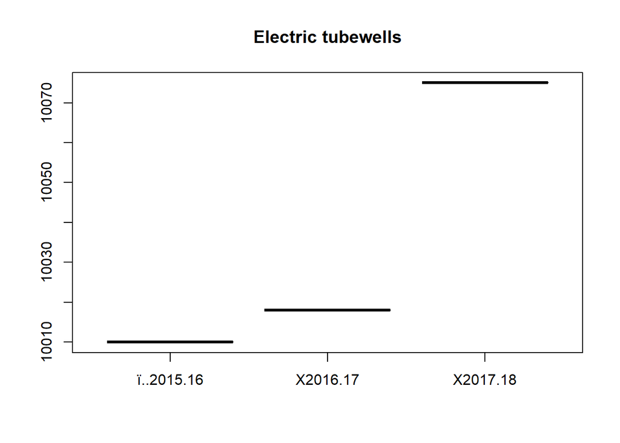

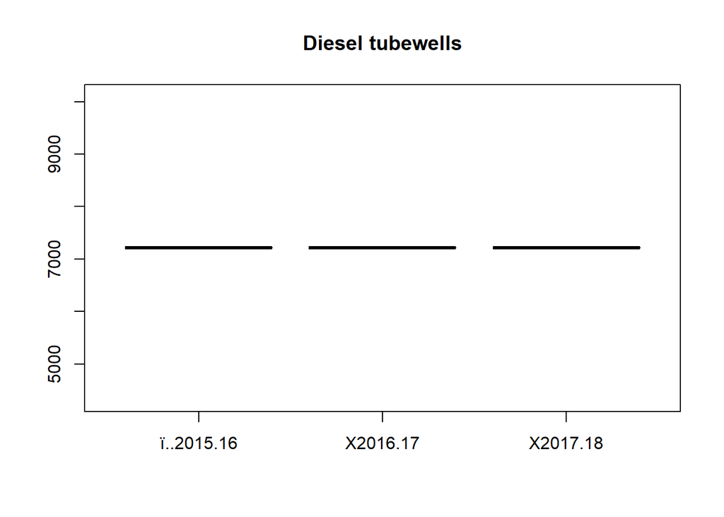

Using Histogram/Bar Chart:

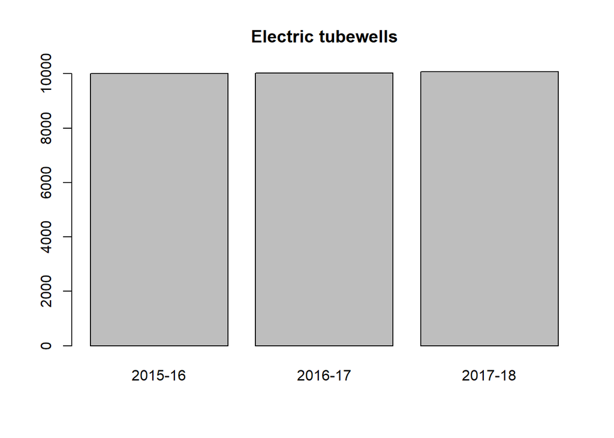

[figure not shown]

#### Analysis of Data:

Summary of data:

[output not shown]

### **Conclusion** : Number of electric tubewells have shown a steady increase while stangnant nature of diesel ones. This is a good sign, as our dependence on crude oil decreases and it is good for the environment too.

## Number of borewells :

Source : Zila Spider Report (http://updes.up.nic.in/spiderreports/gettable23Report.action) Talika 23

#### Let’s take as input the raw data.

```r
data <- read.csv("data_files/borewells.csv", header = TRUE)
```

#### Visualizing the data:

Using box plot :

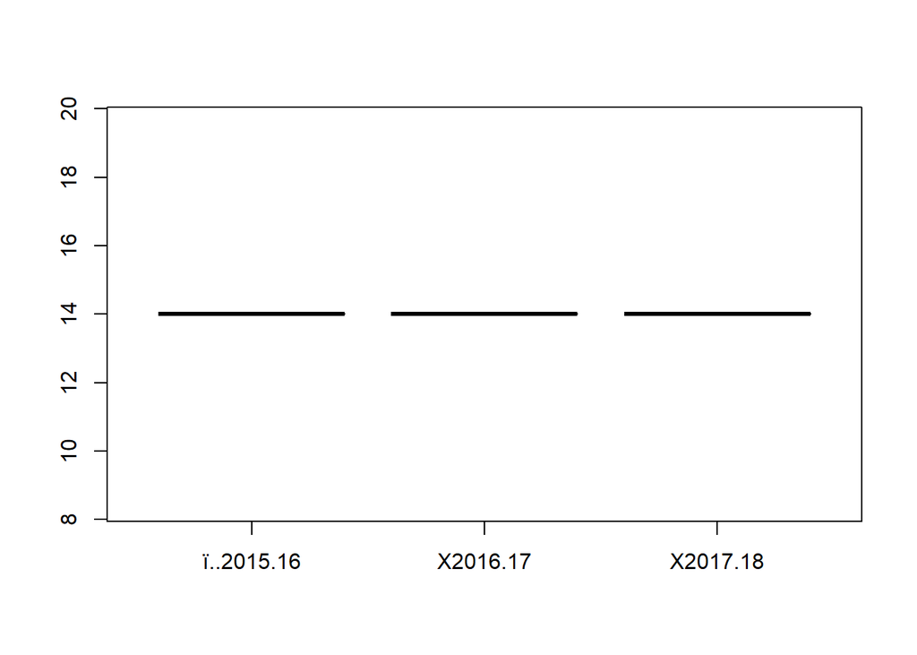

Using Histogram/Bar Chart:

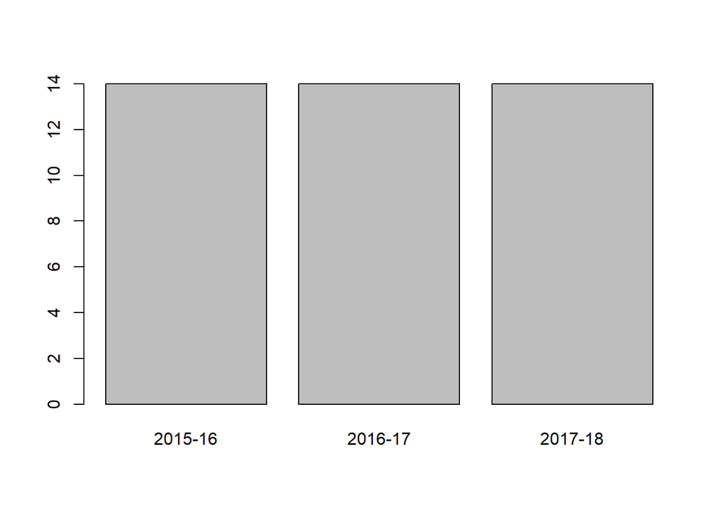

#### Analysis of Data:

Summary of data:

```
##    ï..2015.16    X2016.17     X2017.18
##  Min.   :14   Min.   :14   Min.   :14
##  1st Qu.:14   1st Qu.:14   1st Qu.:14
##  Median :14   Median :14   Median :14
##  Mean   :14   Mean   :14   Mean   :14
##  3rd Qu.:14   3rd Qu.:14   3rd Qu.:14
##  Max.   :14   Max.   :14   Max.   :14
```

### **Conclusion** : Number of borewells haven’t increased over the years, which does sound good for ground water.